This tutorial covers downloading NEON data, using the Data Portal and either the neonUtilities R package or the neonutilities Python package, as well as basic instruction in beginning to explore and work with the downloaded data, including guidance in navigating data documentation. We will explore data of 3 different types, and make a simple figure from each.

## NEON data

There are 3 basic categories of NEON data:

1. Remote sensing (AOP) - Data collected by the airborne observation platform, e.g. LIDAR, surface reflectance
2. Observational (OS) - Data collected by a human in the field, or in an analytical laboratory, e.g. beetle identification, foliar isotopes
3. Instrumentation (IS) - Data collected by an automated, streaming sensor, e.g. net radiation, soil carbon dioxide. This category also includes the surface-atmosphere exchange (SAE) data, which are processed and structured in a unique way, distinct from other instrumentation data (see the introductory [eddy flux data tutorial](https://www.neonscience.org/eddy-data-intro) for details).

This lesson covers all three types of data. The download procedures are similar for all types, but data navigation differs significantly by type.

## Objectives

After completing this activity, you will be able to:

- Download NEON data using the neonUtilities package.
- Understand downloaded data sets and load them into R or Python for analyses.

## Things You’ll Need To Complete This Tutorial

You can follow either the R or Python code throughout this tutorial. * For R users, we recommend using R version 4+ and RStudio. * For Python users, we recommend using Python 3.10+.

## Set up: Install Packages

Packages only need to be installed once, you can skip this step after the first time:

### R

- **neonUtilities**: Basic functions for accessing NEON data.
- **neonOS**: Functions for common data wrangling needs for NEON observational data.
- **terra**: Spatial data package; needed for working with remote sensing data.

```r
install.packages("neonUtilities")
install.packages("neonOS")
install.packages("terra")
```

### Python

- **neonutilities**: Basic functions for accessing NEON data.
- **rasterio**: Spatial data package; needed for working with remote sensing data.
- **dotenv**: For managing environment variables.

```python
pip install neonutilities
pip install rasterio
pip install dotenv
```

### Additional Resources

- [GitHub repository for neonUtilities R package](https://github.com/NEONScience/NEON-Utilities)
- [GitHub repository for neonutilities Python package](https://github.com/NEONScience/NEON-utilities-python)
- [neonUtilities cheat sheet](https://github.com/NEONScience/NEON-utilities/blob/main/cheat-sheet-neonUtilities.pdf). A quick reference guide for users. Focuses on the R package, but applicable to Python as well.

## Set up: Load packages

### R

```r
library(neonUtilities)
library(neonOS)
library(terra)
```

### Python

```python
import neonutilities as nu
import os
import dotenv
import rasterio
import pandas as pd
import matplotlib.pyplot as plt
```

## Getting started: Download data from the Portal

Go to the [NEON Data Portal](http://data.neonscience.org) and download some data! You will need to create a free account to download data, but you do not need an account to explore the data products and documentation on the portal.

To follow the tutorial exactly, download Photosynthetically active radiation (PAR) (DP1.00024.001) data from September-November 2019 at Wind River Experimental Forest (WREF). The downloaded file should be a zip file named NEON_par.zip.

If you prefer to explore a different data product, you can still follow this tutorial. But it will be easier to understand the steps in the tutorial, particularly the data navigation, if you choose a sensor data product for this section.

Once you’ve downloaded a zip file of data from the portal, switch over to R or Python to proceed with coding.

## Stack the downloaded data files: stackByTable()

The `stackByTable()` (or `stack_by_table()`) function will unzip and join the files in the downloaded zip file.

### R

```r
# Modify the file path to match the path to your zip file
stackByTable("~/Downloads/NEON_par.zip")
```

### Python

```python
# Modify the file path to match the path to your zip file
nu.stack_by_table(os.path.expanduser("~/Downloads/NEON_par.zip"))
```

In the directory where the zipped file was saved, you should now have an unzipped folder of the same name. When you open this you will see a new folder called **stackedFiles**, which should contain at least seven files: **PARPAR_30min.csv**, **PARPAR_1min.csv**, **sensor_positions.csv**, **variables_00024.csv**, **readme_00024.txt**, **issueLog_00024.csv**, and **citation_00024_RELEASE-202X.txt**.

## Navigate data downloads: IS

Let’s start with a brief description of each file. This set of files is typical of a NEON IS data product.

- **PARPAR_30min.csv**: PAR data at 30-minute averaging intervals
- **PARPAR_1min.csv**: PAR data at 1-minute averaging intervals
- **sensor_positions.csv**: The physical location of each sensor collecting PAR measurements. There is a PAR sensor at each level of the WREF tower, and this table lets you connect the tower level index to the height of the sensor in meters.
- **variables_00024.csv**: Definitions and units for each data field in the PARPAR_#min tables.
- **readme_00024.txt**: Basic information about the PAR data product.
- **issueLog_00024.csv**: A record of known issues associated with PAR data.
- **citation_00024_RELEASE-202X.txt**: The citation to use when you publish a paper using these data, in BibTeX format.

We’ll explore the 30-minute data. To read the file, use the function `readTableNEON()` or `read_table_neon()`, which uses the variables file to assign data types to each column of data:

### R

```r
par30 <- readTableNEON(
  dataFile="~/Downloads/NEON_par_R/stackedFiles/PARPAR_30min.csv",
  varFile="~/Downloads/NEON_par_R/stackedFiles/variables_00024.csv")
head(par30)
```

```r
par30 <- readTableNEON(
  dataFile="~/Downloads/NEON_par/stackedFiles/PARPAR_30min.csv",
  varFile="~/Downloads/NEON_par/stackedFiles/variables_00024.csv")
head(par30)
```

### Python

```python
par30 = nu.read_table_neon(
  data_file=os.path.expanduser(
    "~/Downloads/NEON_par/stackedFiles/PARPAR_30min.csv"),
  var_file=os.path.expanduser(
    "~/Downloads/NEON_par/stackedFiles/variables_00024.csv"))
# Open the par30 table in the table viewer of your choice
```

Information about each data column can be found in the variables file, where you can see definitions and units for each column of data.

### Plot PAR data

Now that we know what we’re looking at, let’s plot PAR from the top tower level. We’ll use the mean PAR from each averaging interval, and we can see from the sensor positions file that the vertical index 080 corresponds to the highest tower level. To explore the sensor positions data in more depth, see the [spatial data](https://www.neonscience.org/resources/learning-hub/tutorials/neon-spatial-data-basics) tutorial.

#### R

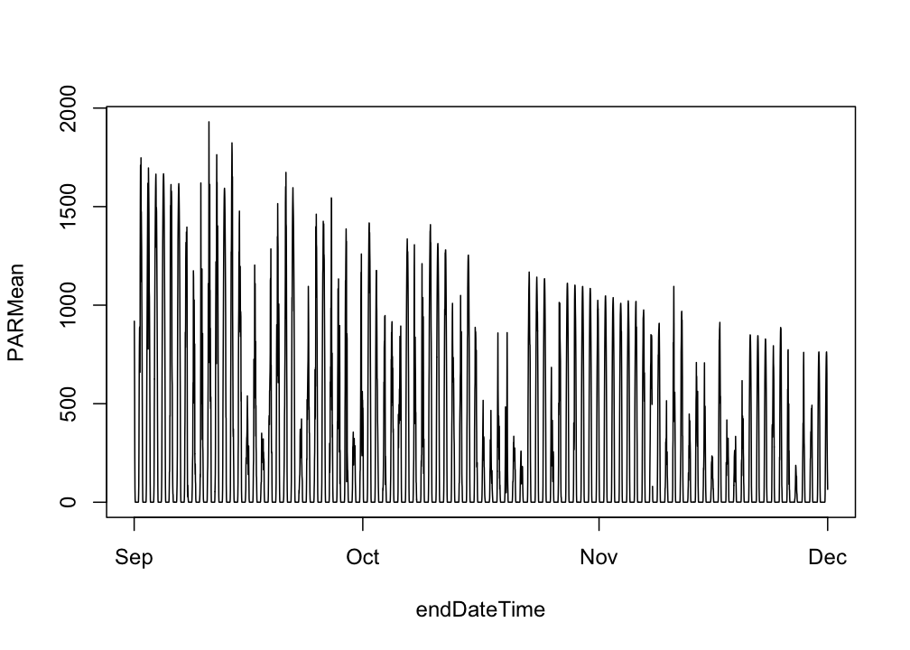

```r
plot(PARMean~endDateTime,
     data=par30[which(par30$verticalPosition=="080"),],
     type="l")
```

#### Python

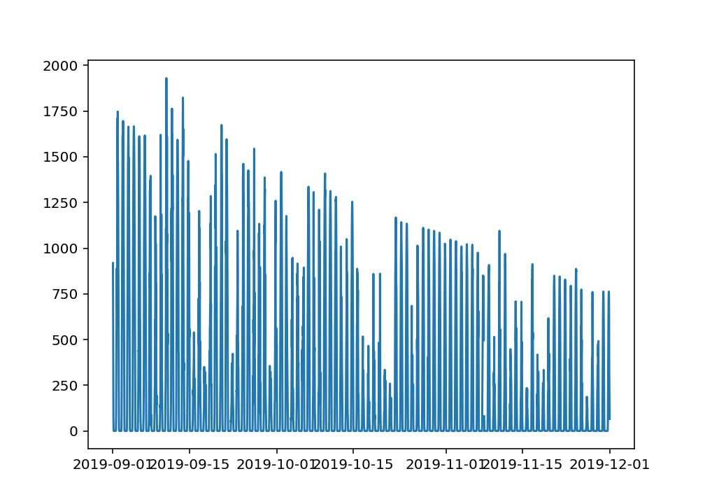

```python
par30top = par30[par30.verticalPosition=="080"]
fig, ax = plt.subplots()
ax.plot(par30top.endDateTime, par30top.PARMean)
plt.show()
```

Looks good! The sun comes up and goes down every day, and some days are cloudy.

### Plot more PAR data

To see another layer of data, add PAR from a lower tower level to the plot.

#### R

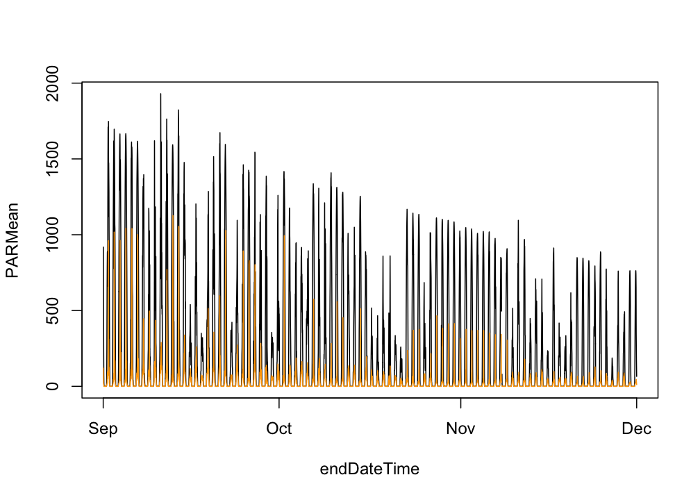

```r
plot(PARMean~endDateTime,
     data=par30[which(par30$verticalPosition=="080"),],
     type="l")

lines(PARMean~endDateTime,
     data=par30[which(par30$verticalPosition=="020"),],
     col="orange")
```

#### Python

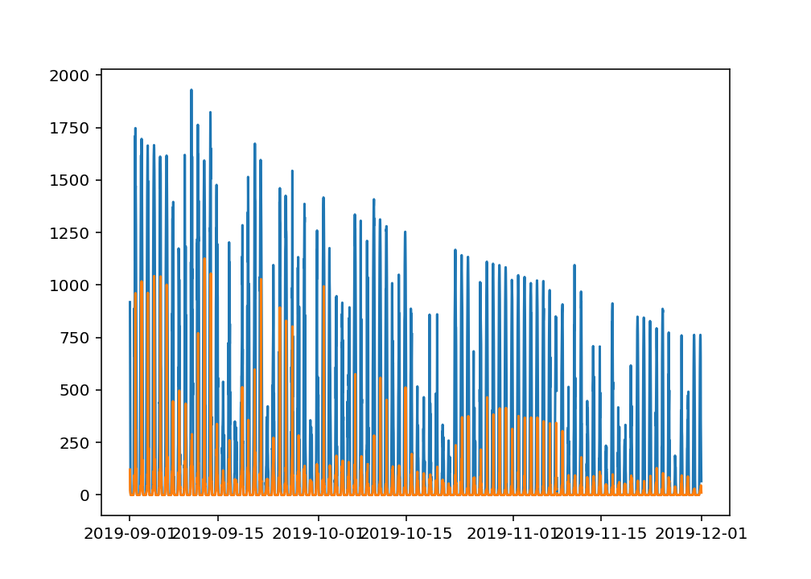

```python
par30low = par30[par30.verticalPosition=="020"]
fig, ax = plt.subplots()
ax.plot(par30top.endDateTime, par30top.PARMean)
ax.plot(par30low.endDateTime, par30low.PARMean)
plt.show()
```

We can see there is a lot of light attenuation through the canopy.

## Download files and load directly to R: loadByProduct()

At the start of this tutorial, we downloaded data from the NEON data portal. NEON also provides an API, and the `neonUtilities` packages provide methods for downloading data programmatically.

The steps we carried out above - downloading from the portal, stacking the downloaded files, and reading in to R or Python - can all be carried out in one step by the neonUtilities function `loadByProduct()`.

Just as the data portal requires a free account to download data, accessing data via the API requires an API token, which you can get through your data portal account. See the [Set up a NEON API token](https://www.neonscience.org/resources/learning-hub/tutorials/api-token-setup) tutorial for instructions on getting a token and setting it up in your code environment.

Now let’s use `loadByProduct()` to get the same PAR data we worked with above.

### R

Retrieve your API token and assign it to an object called `token`, which you will use throughout this tutorial when downloading data. If you stored your token in a different way (i.e., not as an environment variable), modify the code below to match how you stored it.

```r
token <- Sys.getenv("NEON_TOKEN")
```

Download data:

```r
parlist <- loadByProduct(dpID="DP1.00024.001",
                         site="WREF",
                         startdate="2019-09",
                         enddate="2019-11",
                         token=token)
```

### Python

Retrieve your API token and assign it to an object called `token`, which you will use throughout this tutorial when downloading data. If you stored your token in a different way (i.e., not as an environment variable), modify the code below to match how you stored it.

```python
dotenv.load_dotenv()
```

```python
token = os.environ.get("NEON_TOKEN")
```

Download data:

```python
parlist = nu.load_by_product(dpid="DP1.00024.001",
                site="WREF",
                startdate="2019-09",
                enddate="2019-11",
                token=token)
```

### Explore loaded data

The object returned by `loadByProduct()` in R is a named list, and the object returned by `load_by_product()` in Python is a dictionary. The objects contained in the list or dictionary are the same set of tables we ended with after stacking the data from the portal above. You can see this by checking the names of the tables in `parlist`:

#### R

```r
names(parlist)
```

```
## [1] "citation_00024_RELEASE-2026" "issueLog_00024"
## [3] "PARPAR_1min"                 "PARPAR_30min"
## [5] "readme_00024"                "sensor_positions_00024"
## [7] "variables_00024"
```

#### Python

```python
parlist.keys()
```

```
## dict_keys(['PARPAR_1min', 'PARPAR_30min', 'citation_00024_RELEASE-2026', 'issueLog_00024', 'readme_00024', 'sensor_positions_00024', 'variables_00024'])
```

Now let’s walk through the details of the inputs and options in `loadByProduct()`.

This function downloads data from the NEON API, merges the site-by-month files, and loads the resulting data tables into the programming environment, assigning each data type to the appropriate class. This is a popular choice for NEON data users because it ensures you’re always working with the latest data, and it ends with ready-to-use tables. However, if you use it in a workflow you run repeatedly, keep in mind it will re-download the data every time. See below for suggestions on saving the data locally to save time and compute resources.

`loadByProduct()` works on most observational (OS) and sensor (IS) data, but not on surface-atmosphere exchange (SAE) data and remote sensing (AOP) data. For functions that download AOP data, see the final section in this tutorial. For functions that work with SAE data, see the [NEON eddy flux data tutorial](https://www.neonscience.org/eddy-data-intro).

The inputs to `loadByProduct()` control which data to download and how to manage the processing. The list below shows the R syntax; in Python, the inputs are the same but all lowercase (e.g. `dpid` instead of `dpID`) and `.` is replaced by `_`.

The `dpID` is the data product identifier of the data you want to download. The DPID can be found on the [Explore Data Products page](http://data.neonscience.org/data-products/explore). It will be in the form DP#.#####.###

### Download observational data

To explore observational data, we’ll download aquatic plant chemistry data (DP1.20063.001) from three lake sites: Prairie Lake (PRLA), Suggs Lake (SUGG), and Toolik Lake (TOOK).

#### R

```r
apchem <- loadByProduct(dpID="DP1.20063.001",
                  site=c("PRLA","SUGG","TOOK"),
                  package="expanded",
                  release="RELEASE-2024",
                  check.size=F,
                  token=token)
```

```
## Finding available files
```

```
## Unpacking zip files using 1 cores.
```

```
## Stacking data files
```

```
## Finished: Stacked 5 data tables and 5 metadata tables!
```

```
## Stacking took 0.8259289 secs
```

#### Python

```python
apchem = nu.load_by_product(dpid="DP1.20063.001",
                  site=["PRLA", "SUGG", "TOOK"],
                  package="expanded",
                  release="RELEASE-2024",
                  check_size=False,
                  token=token)
```

## Navigate data downloads: OS

As we saw above, the object returned by `loadByProduct()` is a named list of data frames. Let’s check out what’s the same and what’s different from the IS data tables.

### R

```r
names(apchem)
```

```
##  [1] "apl_biomass"                       "apl_clipHarvest"
##  [3] "apl_plantExternalLabDataPerSample" "apl_plantExternalLabQA"
##  [5] "asi_externalLabPOMSummaryData"     "categoricalCodes_20063"
##  [7] "citation_20063_RELEASE-2024"       "issueLog_20063"
##  [9] "readme_20063"                      "validation_20063"
## [11] "variables_20063"
```

### Python

```python
apchem.keys()
```

```
## dict_keys(['apl_biomass', 'apl_clipHarvest', 'apl_plantExternalLabDataPerSample', 'apl_plantExternalLabQA', 'asi_externalLabPOMSummaryData', 'categoricalCodes_20063', 'citation_20063_RELEASE-2024', 'issueLog_20063', 'readme_20063', 'validation_20063', 'variables_20063'])
```

### Explore tables

As with the sensor data, we have some data tables and some metadata tables. Most of the metadata files are the same as the sensor data: **readme**, **variables**, **issueLog**, and **citation**. These files contain the same type of metadata here that they did in the IS data product. Let’s look at the other files:

- **apl_clipHarvest**: Data from the clip harvest collection of aquatic plants
- **apl_biomass**: Biomass data from the collected plants
- **apl_plantExternalLabDataPerSample**: Chemistry data from the collected plants
- **apl_plantExternalLabQA**: Quality assurance data from the chemistry analyses
- **asi_externalLabPOMSummaryData**: Quality metrics from the chemistry lab
- **validation_20063**: For observational data, a major method for ensuring data quality is to control data entry. This file contains information about the data ingest rules applied to each input data field.
- **categoricalCodes_20063**: Definitions of each value for categorical data, such as growth form and sample condition

You can work with these tables from the named list object, but many people find it easier to extract each table from the list and work with it as an independent object. To do this, use the `list2env()` function in R or `globals().update()` in Python:

#### R

```r
list2env(apchem, .GlobalEnv)
```

```
## <environment: R_GlobalEnv>
```

#### Python

```python
globals().update(apchem)
```

### Save data locally

Keep in mind that using `loadByProduct()` will re-download the data every time you run your code. In some cases this may be desirable, but it can be a waste of time and compute resources. To come back to these data without re-downloading, you’ll want to save the tables locally. The most efficient option is to save the named list in total - this will also preserve the data types.

#### R

```r
saveRDS(apchem,
        "~/Downloads/aqu_plant_chem.rds")
```

#### Python

```
# There are a variety of ways to do this in Python; NEON
# doesn't currently have a specific recommendation. If
# you don't have a data-saving workflow you already use,
# we suggest you check out the pickle module.
```

Then you can re-load the object to a programming environment any time.

Other options for saving data locally:

1. Similar to the workflow we started this tutorial with, but using `neonUtilities` to download instead of the Portal: Use `zipsByProduct()` and `stackByTable()` instead of `loadByProduct()`. With this option, use the function `readTableNEON()` to read the files, to get the same column type assignment that `loadByProduct()` carries out. Details can be found in our [neonUtilities tutorial](https://www.neonscience.org/neonDataStackR).
2. Try out the community-developed `neonstore` package, which is designed for maintaining a local store of the NEON data you use. The `neonUtilities` function `stackFromStore()` works with files downloaded by `neonstore`. See the [neonstore tutorial](https://www.neonscience.org/resources/learning-hub/tutorials/neonstore-stackfromstore-tutorial) for more information.

Now let’s explore the aquatic plant data. OS data products are simple in that the data are generally tabular, and data volumes are lower than the other NEON data types, but they are complex in that almost all consist of multiple tables containing information collected at different times in different ways. For example, samples collected in the field may be shipped to a laboratory for analysis. Data associated with the field collection will appear in one data table, and the analytical results will appear in another. Complexity in working with OS data usually involves bringing data together from multiple measurements or scales of analysis.

As with the IS data, the variables file can tell you more about the data tables.

OS data products each come with a Data Product User Guide, which can be downloaded with the data, or accessed from the document library on the Data Portal, or the [Product Details](https://data.neonscience.org/data-products/DP1.20063.001) page for the data product. The User Guide is designed to give a basic introduction to the data product, including a brief summary of the protocol and descriptions of data format and structure.

### Explore isotope data

To get started with the aquatic plant chemistry data, let’s take a look at carbon isotope ratios in plants across the three sites we downloaded. The chemical analytes are reported in the `apl_plantExternalLabDataPerSample` table, and the table is in long format, with one record per sample per analyte, so we’ll subset to only the carbon isotope analyte:

#### R

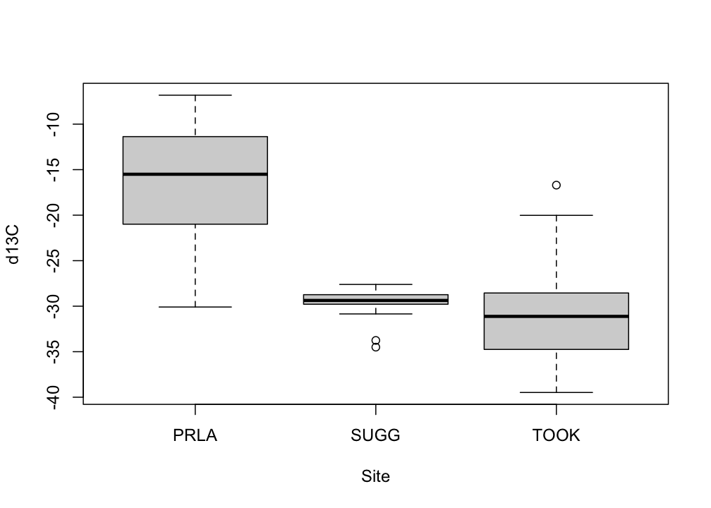

```r
boxplot(analyteConcentration~siteID,
        data=apl_plantExternalLabDataPerSample,
        subset=analyte=="d13C",
        xlab="Site", ylab="d13C")
```

#### Python

```python
apl13C = apl_plantExternalLabDataPerSample[
         apl_plantExternalLabDataPerSample.analyte=="d13C"]
grouped = apl13C.groupby("siteID")["analyteConcentration"]
fig, ax = plt.subplots()
ax.boxplot(x=[group.values for name, group in grouped],
           tick_labels=grouped.groups.keys())
```

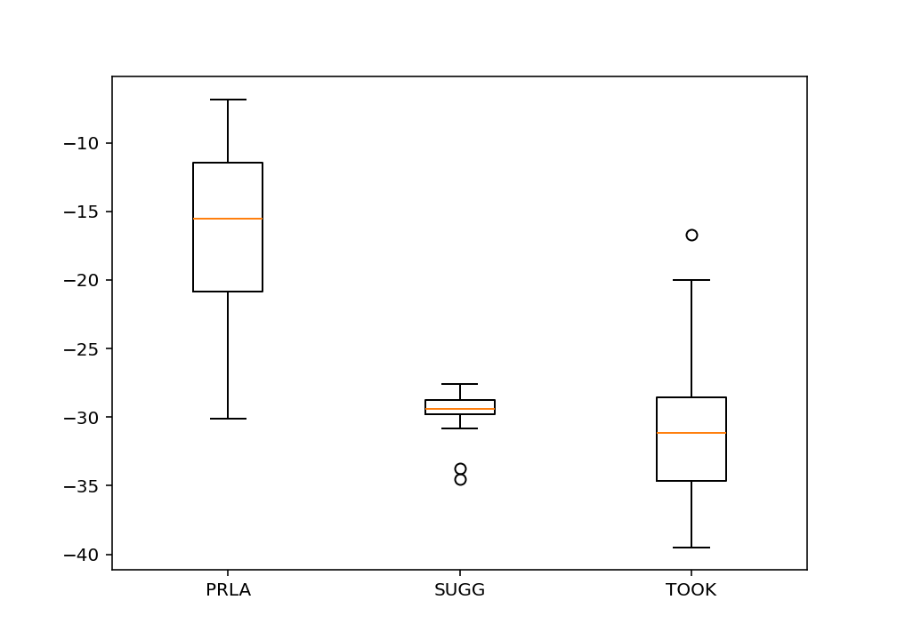

```python
plt.show()
```

We see plants at Suggs and Toolik are quite low in 13C, with more spread at Toolik than Suggs, and plants at Prairie Lake are relatively enriched. Clearly the next question is what species these data represent. But taxonomic data aren’t present in the `apl_plantExternalLabDataPerSample` table, they’re in the `apl_biomass` table. We’ll need to join the two tables to get chemistry by taxon.

Every NEON data product has a Quick Start Guide (QSG), and for OS products it includes a section describing how to join the tables in the data product. Since it’s a pdf file, `loadByProduct()` doesn’t bring it in, but you can view the Aquatic plant chemistry QSG on the [Product Details](https://data.neonscience.org/data-products/DP1.20063.001) page. In R, the `neonOS` package uses the information from the QSGs to provide an automated table-joining function, `joinTableNEON()`.

### Explore isotope data by species

#### R

```r
apct <- joinTableNEON(apl_biomass,
            apl_plantExternalLabDataPerSample)
```

Using the merged data, now we can plot carbon isotope ratio for each taxon.

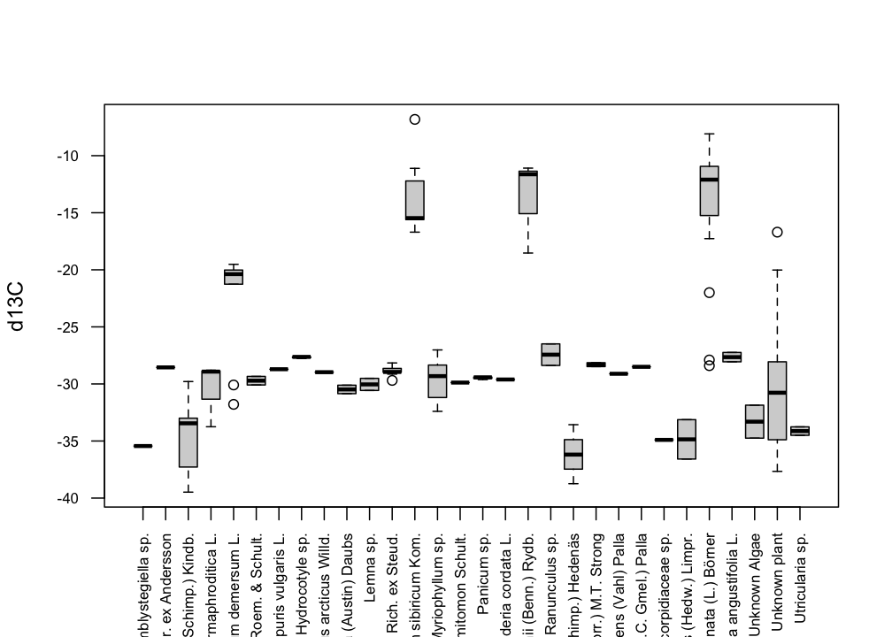

```r
boxplot(analyteConcentration~scientificName,
        data=apct, subset=analyte=="d13C",
        xlab=NA, ylab="d13C",
        las=2, cex.axis=0.7)
```

#### Python

There is not yet an equivalent to the `neonOS` package in Python, so we will code the table join manually, based on the info in the Quick Start Guide:

```python
apct = pd.merge(apl_biomass,
            apl_plantExternalLabDataPerSample,
            left_on=["siteID", "chemSubsampleID"],
            right_on=["siteID", "sampleID"],
            how="outer")
```

Using the merged data, now we can plot carbon isotope ratio for each taxon.

```python
apl13Cspp = apct[apct.analyte=="d13C"]
grouped = apl13Cspp.groupby("scientificName")["analyteConcentration"]
fig, ax = plt.subplots()
ax.boxplot(x=[group.values for name, group in grouped],
           tick_labels=grouped.groups.keys())
```

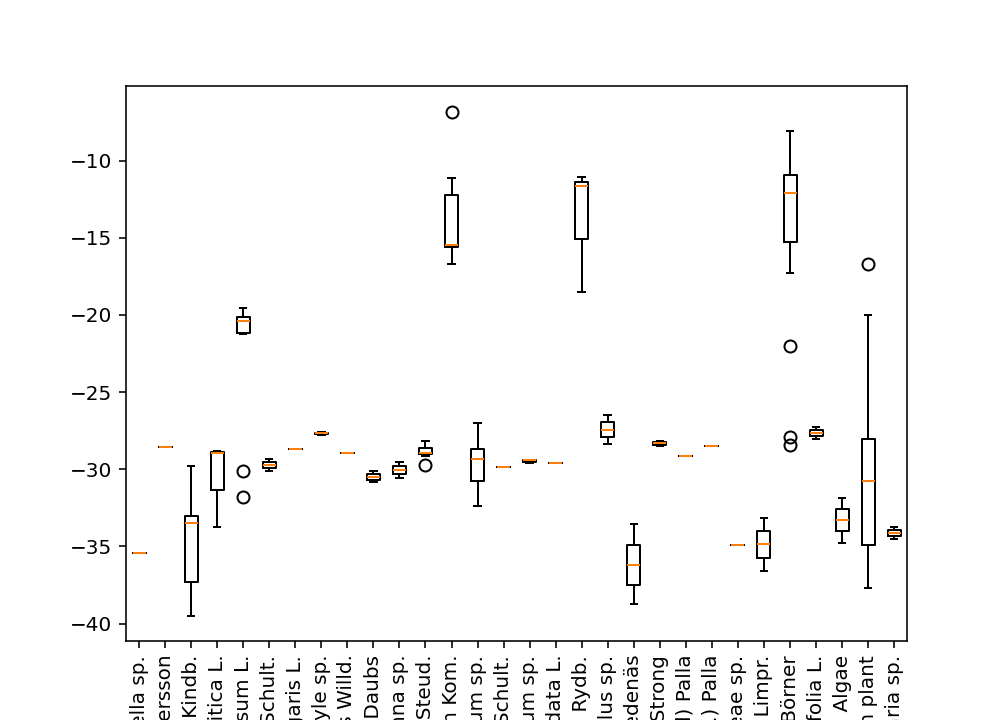

```python
ax.tick_params(axis='x', labelrotation=90)
plt.show()
```

And now we can see most of the sampled plants have carbon isotope ratios around -30, with just a few species accounting for most of the more enriched samples.

## Download remote sensing data: byFileAOP() and byTileAOP()

Remote sensing data files are very large, so downloading them can take a long time. `byFileAOP()` and `byTileAOP()` enable easier programmatic downloads, but be aware it can take a very long time to download large amounts of data.

Input options for the AOP functions are:

- `dpID`: the data product ID, e.g. DP1.00002.001
- `site`: the 4-letter code of a single site, e.g. HARV
- `year`: the 4-digit year to download
- `savepath`: the file path you want to download to; defaults to the working directory
- `check.size`: T or F: should the function pause before downloading data and warn you about the size of your download? Defaults to T; if you are using this function within a script or batch process you will want to set it to F.
- `easting`: `byTileAOP()` only. Vector of easting UTM coordinates whose corresponding tiles you want to download
- `northing`: `byTileAOP()` only. Vector of northing UTM coordinates whose corresponding tiles you want to download
- `buffer`: `byTileAOP()` only. Size in meters of buffer to include around coordinates when deciding which tiles to download
- `token`: NEON API token.
- `chunk_size`: Only in Python. Set the chunk size of chunked downloads, can improve efficiency in some cases. Defaults to 1 MB.

Here, we’ll download one tile of Ecosystem structure (Canopy Height Model) (DP3.30015.001) from WREF in 2017.

### R

```r
byTileAOP(dpID="DP3.30015.001", site="WREF",
          year=2017,easting=580000,
          northing=5075000,
          token=token,
          savepath="~/Downloads")
```

### Python

```python
nu.by_tile_aop(dpid="DP3.30015.001", site="WREF",
               year=2017,easting=580000,
               northing=5075000,
               token=token,
               savepath=os.path.expanduser(
                 "~/Downloads"))
```

In the directory indicated in `savepath`, you should now have a folder named `DP3.30015.001` with several nested subfolders, leading to a tif file of a canopy height model tile.

## Navigate data downloads: AOP

To work with AOP data, the best bet in R is the `terra` package. It has functionality for most analyses you might want to do. In Python, we’ll use the rasterio package here; explore NEON remote sensing tutorials for more guidance.

First let’s read in the tile we downloaded:

### R

```r
chm <- rast("~/Downloads/DP3.30015.001/neon-aop-products/2017/FullSite/D16/2017_WREF_1/L3/DiscreteLidar/CanopyHeightModelGtif/NEON_D16_WREF_DP3_580000_5075000_CHM.tif")
```

### Python

```python
chm = rasterio.open(os.path.expanduser("~/Downloads/DP3.30015.001/neon-aop-products/2017/FullSite/D16/2017_WREF_1/L3/DiscreteLidar/CanopyHeightModelGtif/NEON_D16_WREF_DP3_580000_5075000_CHM.tif"))
```

### Plot canopy height model

#### R

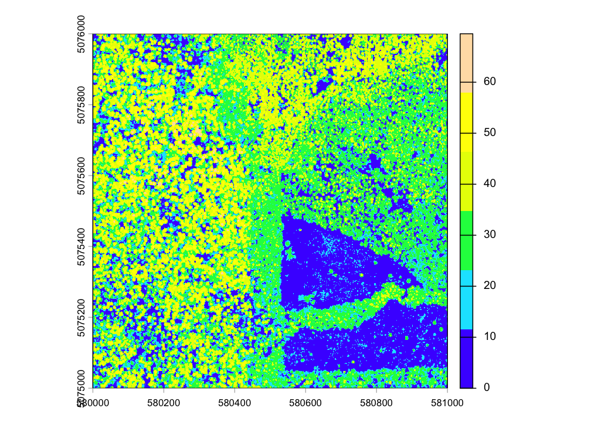

```r
plot(chm, col=topo.colors(6))
```

#### Python

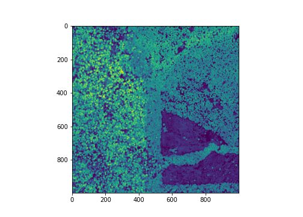

```python
plt.imshow(chm.read(1))
plt.show()
```

Now we can see canopy height across the downloaded tile; the tallest trees are over 60 meters, not surprising in the Pacific Northwest. There is a clearing or clear cut in the lower right quadrant.

## Next steps

Now that you’ve learned the basics of downloading and understanding NEON data, where should you go to learn more? There are many more NEON tutorials to explore, including how to align remote sensing and ground-based measurements, a deep dive into the data quality flagging in the sensor data products, and much more. For a recommended suite of tutorials for new users, check out the [Getting Started with NEON Data](https://www.neonscience.org/resources/learning-hub/tutorials/get-started-neon-data-series-data-tutorials) tutorial series.